# Reproducible Research: Peer Assessment 1

Zárate-Salazar, J. Rafael

30 setembro, 2024

## Peer-graded Assignment: Course Project 1

## Loading Library

```r
knitr::opts_chunk$set(echo = TRUE)
library(conflicted)
library(tidyverse)
library(here)
```

## Loading and preprocessing the data

```r
fullData <- read.csv(file = here::here("activity","activity.csv"))
fullData$date <- as.Date(fullData$date, "%Y-%m-%d")
```

# A. What is mean total number of steps taken per day?

### 1. Calculate the total steps per day

```r
stepsPerDay <- aggregate(steps ~ date, fullData, FUN = sum)
```

### 2. Make a histogram of the total number of steps taken each day

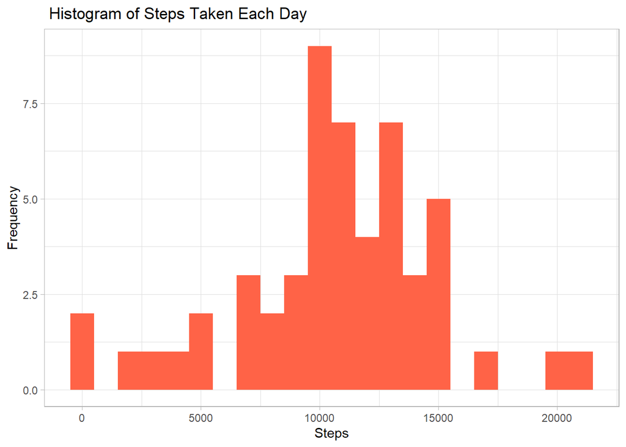

```r
g <- ggplot (stepsPerDay, aes (x = steps))
g + geom_histogram(fill = "tomato", binwidth = 1000) +
    labs(title = " Histogram of Steps Taken Each Day ", x = "Steps", y = "Frequency") +
  ggplot2::theme_light()
```

### 3. Calculate and report the mean and median of the total number of steps taken per day

### - Mean of steps

```r
stepsMean <- mean(stepsPerDay$steps, na.rm=TRUE)
stepsMean
```

```
## [1] 10766.19
```

### - Median of steps

```r
stepsMedian <- median(stepsPerDay$steps, na.rm=TRUE)
stepsMedian
```

```
## [1] 10765
```

Therefore, the mean and median of the total number of steps taken per day are 10766.19 and 10765 respectively.

# B. What is the average daily activity pattern?

### 1. Make a time series plot (i.e. type=“l”) of the 5-minute interval (x-axis) and the average number of steps taken, averaged across all days (y-axis)

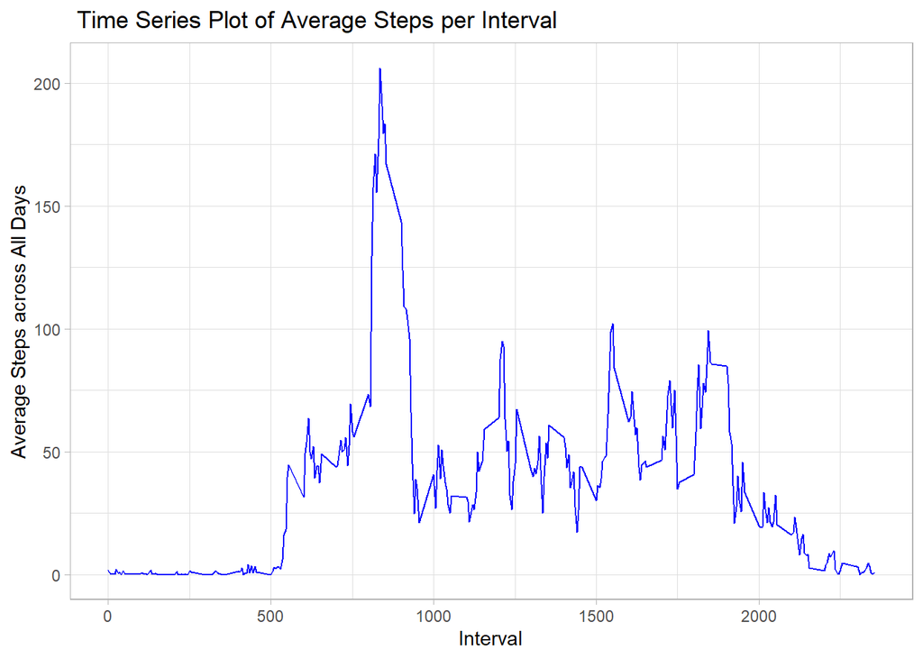

```r
# create average number of steps per 5-min interval
stepsPerInterval <- aggregate(steps ~ interval, fullData, mean)

# Create a time series plot of average number of steps per interval, annotate the plot
h <- ggplot (stepsPerInterval, aes(x = interval, y = steps))
h + geom_line(colour = 'blue')+ labs(title = " Time Series Plot of Average Steps per Interval"
                      , x = "Interval", y = "Average Steps across All Days")+
  ggplot2::theme_light()
```

### 2. Which 5-minute interval, on average across all the days in the dataset, contains the maximum number of steps?

### - Maximum steps by interval

```r
maxInterval <- stepsPerInterval[which.max(stepsPerInterval$steps), ]
maxInterval
```

```
##     interval    steps
## 104      835 206.1698
```

# C. Imputing missing values

### 1. Calculate and report the total number of missing values in the dataset (i.e. the total number of rows with NAs)

### - Number of NAs in the original dataset

```r
noMissingValue <- nrow(fullData[is.na(fullData$steps),])
noMissingValue
```

```
## [1] 2304
```

### 2. Devise a strategy for filling in all of the missing values in the dataset. The strategy does not need to be sophisticated. For example, you could use the mean/median for that day, or the mean for that 5-minute interval, etc.

Substitute the missing values (steps) with the average number of steps based on both the 5-minute interval and the day of the week

```r
fullData1 <- read.csv("activity.csv", header=TRUE,sep=",")
```

### - Create a variable/column with weekdays name

```r
fullData1$day <- weekdays(as.Date(fullData1$date))
```

### - Create average number of steps per 5-min interval and day

```r
stepsAvg1 <- aggregate(steps ~ interval + day, fullData1, mean)
```

### - Create dataset with all NAs for substitution

```r
nadata <- fullData1 [is.na(fullData1$steps),]
```

### - Merge NAs dataset with the average steps based on 5-min interval+weekdays, for substitutions

```r
newdata1 <- merge(nadata, stepsAvg1, by=c("interval", "day"))
```

### 3. Create a new dataset that is equal to the original dataset but with the missing data filled in.

### - Pull data without NAs

```r
cleanData <- fullData1 [!is.na(fullData1$steps),]
```

### - Reorder the new substituted data in the same format as the clean data set (Leave out the NAs column which will be substituted by the average steps based on 5-min interval + day)

```r
newdata2 <- newdata1[,c(5,4,1,2)]
colnames(newdata2) <- c("steps", "date", "interval", "day")
```

### - Merge the new average data (NAs) with the dataset without NAs

```r
mergeData <- rbind (cleanData, newdata2)
```

### 4. Make a histogram of the total number of steps taken each day and Calculate and report the mean and median total number of steps taken per day. Do these values differ from the estimates from the first part of the assignment? What is the impact of imputing missing data on the estimates of the total daily number of steps?

### - Calculate the total steps per day on the merged data

```r
stepsPerDayFill <- aggregate(steps ~ date, mergeData, FUN = sum)
```

### - Create the histogram

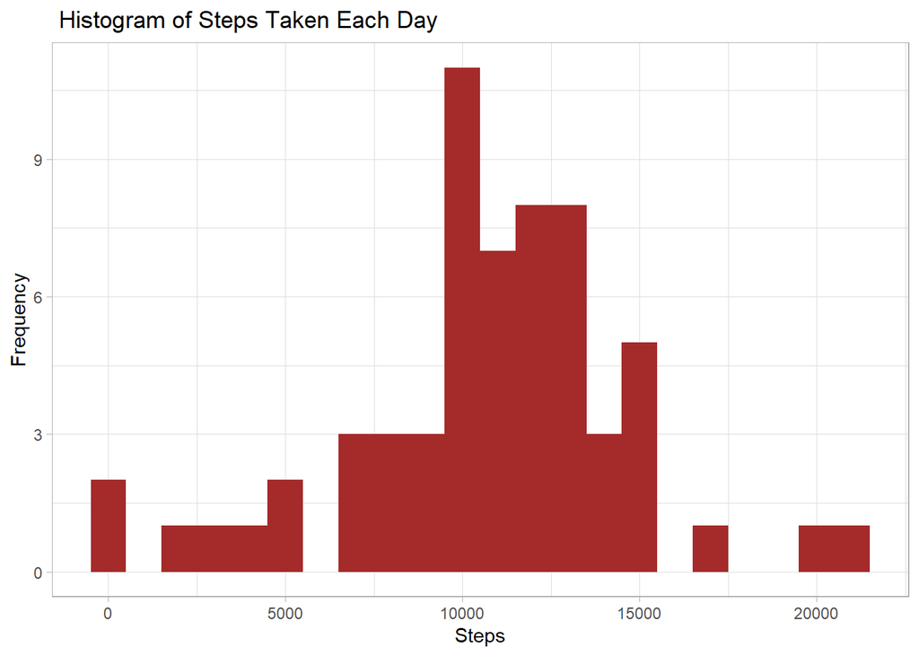

```r
g1 <- ggplot (stepsPerDayFill, aes (x = steps))
g1 + geom_histogram(fill = "brown", binwidth = 1000) +
    labs(title = " Histogram of Steps Taken Each Day ", x = "Steps", y = "Frequency")+
  ggplot2::theme_light()
```

### - Mean of total steps with imputed data

```r
stepsMeanFill <- mean(stepsPerDayFill$steps, na.rm=TRUE)
stepsMeanFill
```

```
## [1] 10821.21
```

### - Median of total steps with imputed data

```r
stepsMedianFill <- median(stepsPerDayFill$steps, na.rm=TRUE)
stepsMedianFill
```

```
## [1] 11015
```

The new mean of the imputed data is 10821.21 steps compared to the old mean of 10766.19 steps. That creates a difference of 55.0209226 steps on average per day.

The new median of the imputed data is 11015 steps compared to the old median of 10765 steps. That creates a difference of 250 steps for the median.